# Postmates (Jumpman23)

Kevin Li

3/4/2018

**Jumpman23 Analysis** Read in necessary packages and data file

```r
#load in data and add libraries
library(readr)
library(dplyr)
library(magrittr)
library(ggplot2)
library(lubridate)
library(geosphere)
library(ggplot2)
library(RColorBrewer)
library(ggthemes)
library(gridExtra)
library(stringr)
pm <- read_csv("analyze_me.csv")
```

Understand dimensions and data types. We will be working with a 5983 X 18 data frame. Summary/overview of data looks like we will be dealing with delivery data for Jumpman23. List of variables that catch my eye are lat/lon variables, as well as POSIXct variables. Further derivation will probably have to be computed from these variables. We might also have to work with strings when aggregating by restaurant. I recommend that Jumpman23 assign unique IDs for pickup_place, as well as another ID to distinguish by location.

```r
#understand the data on a high level
dim(pm)
```

```
## [1] 5983   18
```

```r
#str(pm)
```

Extract time attributes in minutes, hours and seconds. We want to calculate the amount of time that it took for a delivery to complete, an order to be placed, the amount of time it took for pickup, and the amount of time it took for food to be delivered after the pickup.

```r
#create variables for: total time, total pickup time, total order time, total delivery time
pm <- as.data.frame(pm)
pm <-
  pm %>%
  mutate(
    pick_up_wait_secs =  difftime(when_the_Jumpman_left_pickup, when_the_Jumpman_arrived_at_pickup, units = "secs"),
    total_time_secs =  difftime(when_the_Jumpman_arrived_at_dropoff, when_the_delivery_started, units = "secs"),
    order_time_secs = period_to_seconds(hms(pm$how_long_it_took_to_order)),
    pick_up_wait_mins =  difftime(when_the_Jumpman_left_pickup, when_the_Jumpman_arrived_at_pickup, units = "mins"),
    total_time_mins =  difftime(when_the_Jumpman_arrived_at_dropoff, when_the_delivery_started, units = "mins"),
    total_time_hours =  difftime(when_the_Jumpman_arrived_at_dropoff, when_the_delivery_started, units = "hours"),
    order_time_mins = period_to_seconds(hms(pm$how_long_it_took_to_order))/60,
    delivery_time_secs = difftime( when_the_Jumpman_arrived_at_dropoff, when_the_Jumpman_left_pickup, units = "secs"),
    delivery_time_mins = difftime(when_the_Jumpman_arrived_at_dropoff, when_the_Jumpman_left_pickup, units = "mins")
  )
```

Extract the distance traveled from pickup to drop-off via the Haversine formula of provided lon and lat coordinates. Convert into miles and meters. Then, compute miles per hour traveled by dividing distance traveled by delivery time in miles.

```r
#create variables for distance traveled from pick up to dropoff
pm <-
  pm %>%
  mutate(
   miles_traveled = (distHaversine(cbind(pm$pickup_lon,pm$pickup_lat), cbind(pm$dropoff_lon, pm$dropoff_lat))/1609.34),
   meters_traveled = (distHaversine(cbind(pm$pickup_lon,pm$pickup_lat), cbind(pm$dropoff_lon, pm$dropoff_lat)))
  )

#create variables for speed traveled, mph, metersph
pm <-
  pm %>%
  mutate(
    mph = miles_traveled/(as.numeric(delivery_time_mins/60)),
    mpminue = miles_traveled/(as.numeric(delivery_time_mins)),
    metersph = meters_traveled/(as.numeric(delivery_time_mins/60)),
    meterpminue = meters_traveled/as.numeric(delivery_time_mins)
  )
```

```r
#identify outliers and oddities in data
which(pm$pick_up_wait_mins > pm$total_time_mins) #!!!wait time greater than total time, not possible
```

```
## [1] 1025 1559 1920
```

```r
which(pm$order_time_secs > pm$total_time_secs)#nothing wrong here
```

```
## integer(0)
```

```r
which(pm$order_time_mins == pm$pick_up_wait_mins)#nothing wrong here
```

```
## integer(0)
```

```r
#remove deliveries where vehicle type is bike and mph > 40, or when vehicle type is walking and mph is greater than 20
pm <- pm %>%
  filter(
    (vehicle_type == 'bicycle' & mph < 40 | is.na(mph))|
    vehicle_type %in% c("car", "motorcycle", "scooter", "van", "truck" ) |
    (vehicle_type == 'walker' & mph < 20 | is.na(mph))
  )

#remove occurrance where total delivery time exceeds 4 hours.
pm <- pm[-(which(pm$total_time_hours > 4)),]

#remove values where proabbility of occurrance is zero (pickup time is greater than delivery time)
pm <- pm[-(which(pm$pick_up_wait_mins > pm$total_time_mins)),]

#data exploration, 896 unique pickup places
pm %>%
  group_by(pickup_place) %>%
  summarise(count = n()) %>%
  nrow
```

```
## [1] 896
```

```r
#remove non alphanumeric characters
pm$pickup_place <- str_replace_all(pm$pickup_place, "[[:punct:]]", "")
#upper case all pickup places
pm$pickup_place <- toupper(pm$pickup_place)

#remove archived, closed, and depreciated.
pm <- pm %>%
  filter(!grepl('ARCHIVED',pickup_place),
         !grepl('CLOSED',pickup_place),
         !grepl('DEPRECATED',pickup_place)
         )
#896 unique pickup places now reduced to 879 unique pickup places (about 17)
pm %>%
  group_by(pickup_place) %>%
  summarise(count = n()) %>%
  nrow
```

```
## [1] 879
```

```r
#pm %>%
 # group_by(place_category) %>%
  #summarise(count = n())#no anomolies found except for missing data

pm %>%
  group_by(delivery_id) %>%
  summarise(count = n()) %>%
  arrange(desc(count)) %>%
  head()#multiple delivery ids per row. Needs to concatinate Item name, and item category name, max(all other variables), sum(item quantity)
```

```
## # A tibble: 6 × 2
##   delivery_id count
##         <int> <int>
## 1     1460296     5
## 2     1285292     4
## 3     1286826     4
## 4     1302788     4
## 5     1319971     4
## 6     1343610     4
```

```r
#create new variables to merge item names and item categories by delivery id
pm <- pm %>%
  group_by(delivery_id) %>%

  mutate(
  Item_names = paste0(item_name, collapse = ","),
  Item_categories = paste0(item_category_name, collapse = ","),
  total_quantity = sum(item_quantity)
  )

#select distinct values. Moving forward we will only work with Item_names, Item_categories, and total_quantity only. Ignore original values
pm <- as.data.frame(pm[!duplicated(pm$delivery_id), ])
```

Now lets look at the data to answer some high level questions about the performance of the New York market.

Average/Median MPH

An interesting thing to note is that for cars, trucks and vans, we see an increased average wait time compared to walkers, bicycles, scooters, motorcycles. This is probably due to the fact that parking is required often times for pickup. Jumpman might benefit through designated parking spots, or promoting bicycles/walking more. If we look at the max distance traveled, we see that a walker had traveled 5.8 miles to deliver food. Moving forward, consider limiting the amount you can walk because this is not efficient use of time. According to Wikipedia, the average walking MPH is 3. This would have taken 2 hours.

```r
#average and Median MPH by transportation type
#this data should be looked at after normalizing above data


pm %>%
  group_by(vehicle_type) %>%
 summarise(
   average_wait_time = mean(delivery_time_mins, na.rm = 'T'),
   max_distance_traveled = max(miles_traveled)
 )
```

```
## # A tibble: 7 × 3
##   vehicle_type average_wait_time max_distance_traveled
##          <chr>            <time>                 <dbl>
## 1      bicycle     13.01963 mins              4.704756
## 2          car     16.97953 mins              7.785472
## 3   motorcycle     12.70232 mins              4.781253
## 4      scooter     12.83046 mins              5.161748
## 5        truck     24.84018 mins              7.441444
## 6          van     17.02508 mins              6.647292
## 7       walker     14.19680 mins              5.856438
```

Most popular delivery types

We see that the most popular form of delivery type is via bike. This makes the most sense, as the crowded streets of NY might best be navigated through bicycle. Walking and car are also other popular forms of transportation. Jumpman23 might want to further consider promoting bicycles as a good form of transportation as it is the most efficient and green method for deliveries < 1.5 miles, while having the least expensive operating costs for employees.

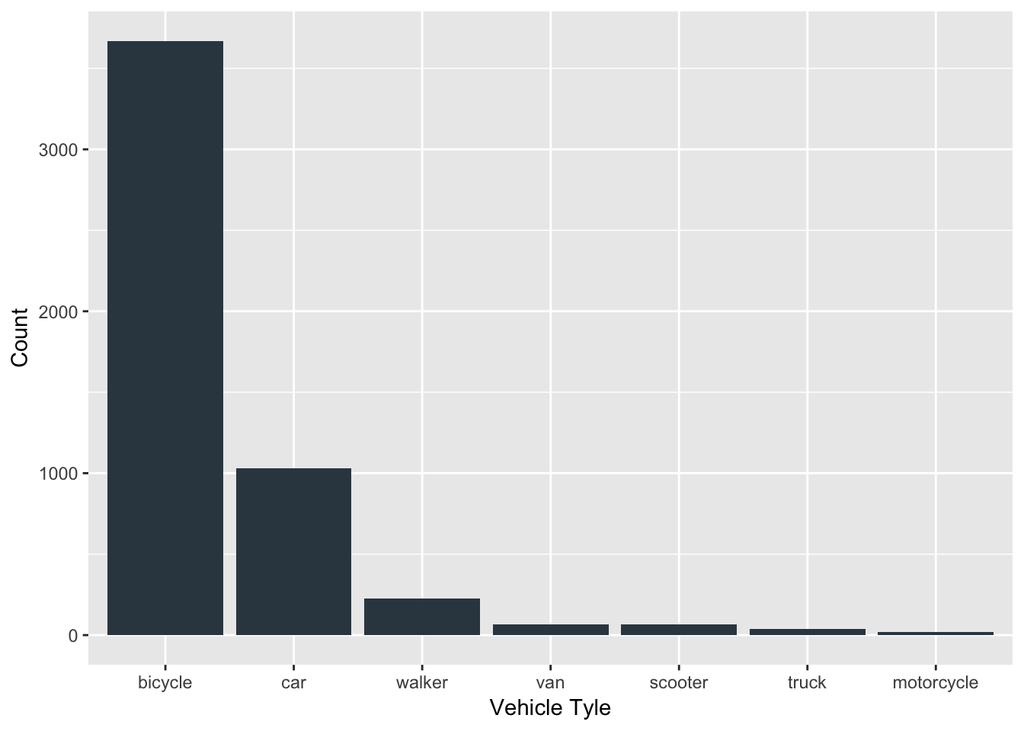

```r
pm %>%
  group_by(vehicle_type) %>%
  summarise(
    count = n()
  ) %>%
  arrange(desc(count)) %>%
     ggplot(aes(x = reorder(vehicle_type, -count), y = count)) +
      geom_bar(stat="identity", fill = "#36454f") +
      labs(x="Vehicle Tyle", y="Count")
```

The most popular places in New York are Shake Shack, Momofuku Milk Bar, The Meatball Shop, and Sweetgreen. Jumpman23 can consider featuring most popular restaurants in the front page of app to test if this drives conversion rate, or reduces average time spent on app before ordering, or a tab with most popular restaurants. Jumpman23 can also consider featuring less popular restaurants to boost sales through partnership deals.

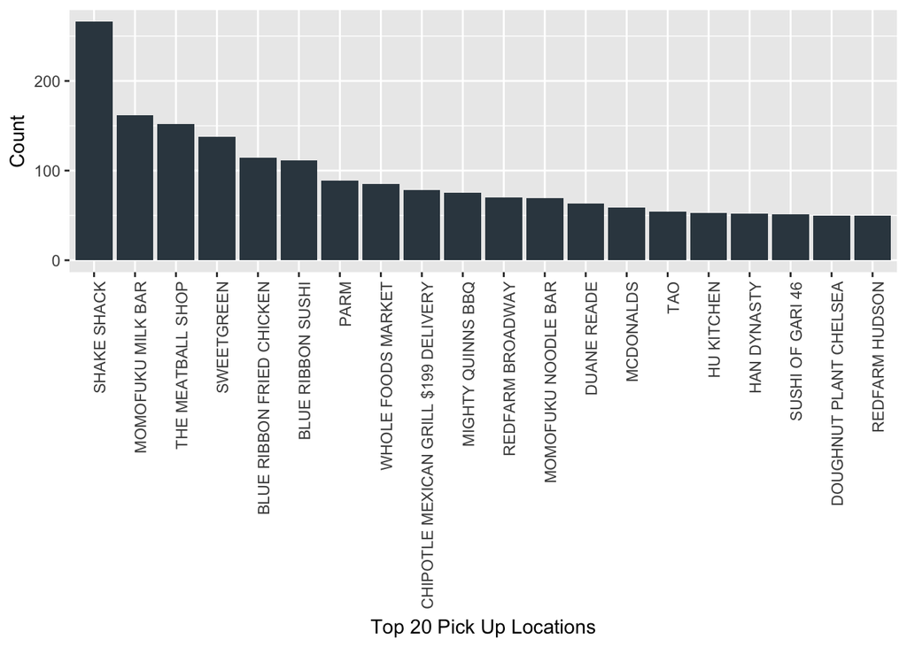

```r
pm %>%
  group_by(pickup_place) %>%
  summarise(
    count = n()
  ) %>%
  arrange(desc(count)) %>%
  top_n(20) %>%
     ggplot(aes(x = reorder(pickup_place, -count), y = count)) +
      geom_bar(stat="identity", fill = "#36454f") +
      labs(x="Top 20 Pick Up Locations", y="Count") +
      theme(axis.text.x = element_text(angle = 90, hjust = 1))
```

Most popular place categories are Italian, Burger, and American. Also consider a navigation option filtered by most popular place categories on app. Conduct test to determine if effective.

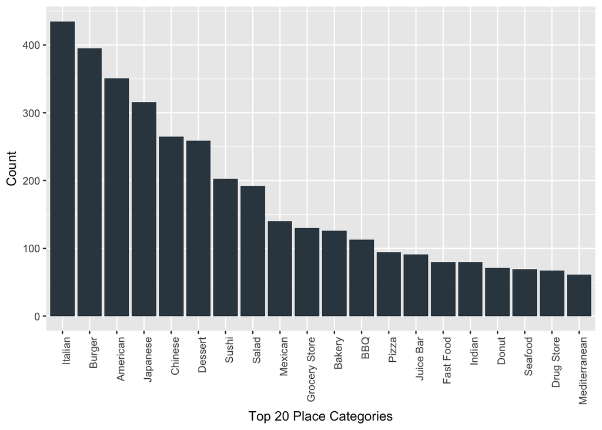

```r
pm %>%
  group_by(place_category) %>%
  summarise(
    count = n()
  ) %>%
  arrange(desc(count)) %>%
  filter(!is.na(place_category)) %>%
  top_n(20) %>%
     ggplot(aes(x = reorder(place_category, -count), y = count)) +
      geom_bar(stat="identity", fill = "#36454f") +
      labs(x="Top 20 Place Categories", y="Count") +
      theme(axis.text.x = element_text(angle = 90, hjust = 1))
```

Are top employees also the fastest?

Without conducting statistical t-tests, it looks at first glance that the top jumpmen tend to deliver on average at a faster rate than the average and bottom jumpman in terms of total deliveries made. Consider creating programs to reward delivery time, or to help average jumpmen to be top jumpmen. Improving Jumpman23 to jumpmen client relationship might increase overall efficiency.

```r
mean(pm$delivery_time_mins, na.rm = 'T')
```

```
## Time difference of 14.01538 mins
```

```r
#top jumpmen and average delivery times
pm %>%
  group_by(jumpman_id) %>%
  summarise(
    count = n(),
    mean(delivery_time_mins, na.rm = 'T')
  ) %>%
  arrange(desc(count)) %>% head()
```

```
## # A tibble: 6 × 3
##   jumpman_id count `mean(delivery_time_mins, na.rm = "T")`
##        <int> <int>                                  <time>
## 1      99219    67                          10.620832 mins
## 2     104533    65                          12.593954 mins
## 3     142394    64                          13.997829 mins
## 4      30743    51                          10.897292 mins
## 5       3296    49                           8.635504 mins
## 6      23359    47                          11.293432 mins
```

```r
#bottom jumpmen and average delivery times
pm %>%
  group_by(jumpman_id) %>%
  summarise(
    count = n(),
    mean(delivery_time_mins, na.rm = 'T')
  ) %>%
  arrange(desc(count)) %>% tail()
```

```
## # A tibble: 6 × 3
##   jumpman_id count `mean(delivery_time_mins, na.rm = "T")`
##        <int> <int>                                  <time>
## 1     176223     1                          16.550064 mins
## 2     176250     1                          11.366877 mins
## 3     177125     1                          25.326227 mins
## 4     177184     1                          29.321045 mins
## 5     177485     1                           5.718834 mins
## 6     179183     1                          15.896346 mins
```

Mapping

First, we map the most popular pickup locations. It seems that there are groups clustered around the city that have the hottest pickup locations.

Consider having a feature in Jumpman app that notifies Jumpmen of local hotspots (based on time of day) to optimize distance traveled between Jumpman starting location and pickup place.

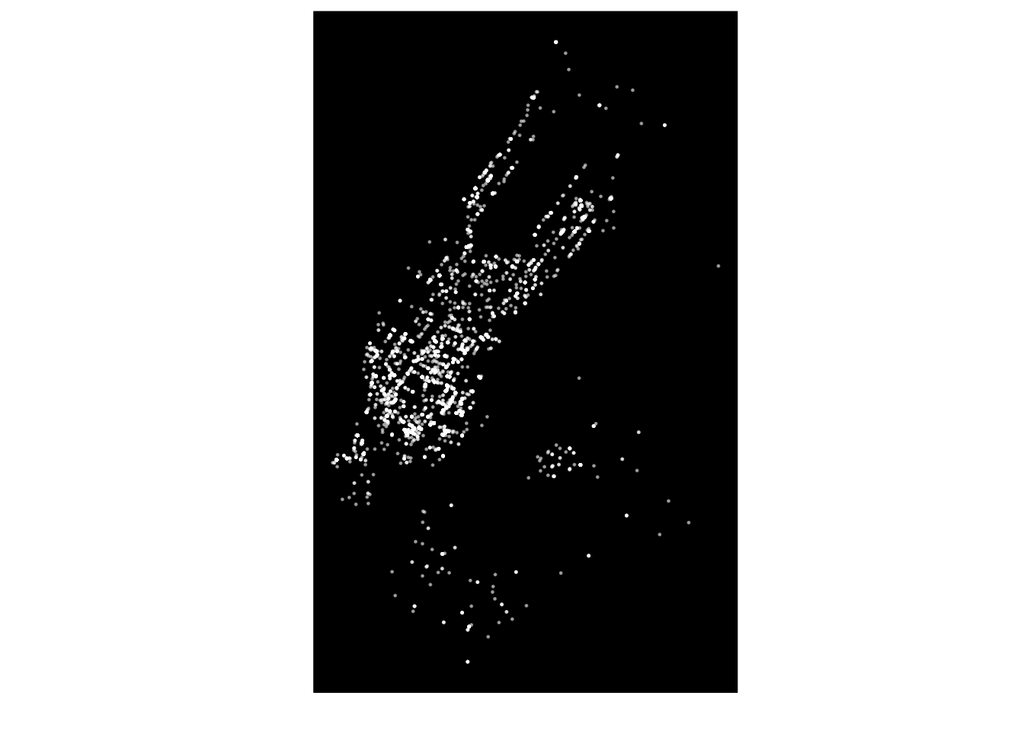

```r
xquiet<- scale_x_continuous("", breaks=NULL)
yquiet<-scale_y_continuous("", breaks=NULL)
quiet<-list(xquiet, yquiet)

#make a filler variable
pm <-  pm %>%
   mutate(filler = 1)
#create dataframes from pm grouped by transport type
pmbike <- pm %>% filter(vehicle_type == 'bicycle')
pmcar <- pm %>% filter(vehicle_type == 'car')
pmMoto <- pm %>% filter(vehicle_type == 'motorcycle')
pmscooter <- pm %>% filter(vehicle_type == 'scooter')
pmtruck <- pm %>% filter(vehicle_type == 'truck')
pmvan <- pm %>% filter(vehicle_type == 'van')
pmwalker <- pm %>% filter(vehicle_type == 'walker')

#popular pickup locations
ggplot(pm, aes(pm$pickup_lon, pm$pickup_lat))+
    geom_point(aes(x=pm$pickup_lon, y=pm$pickup_lat, alpha=filler), col='white', size = .2)+
    scale_alpha_continuous(range = c(0.01, 0.9), guide = FALSE)+
  theme(panel.background = element_rect(fill='black',colour='black'))+
  quiet+
  coord_equal()+
  scale_color_brewer(palette="Pastel1")
```

Note that this graphs looks at the path in a straight line. We are not able to map out actual routes taken.

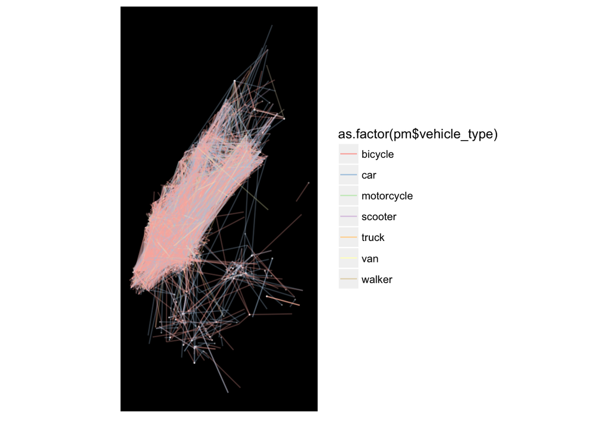

```r
#popular trips by vehicle types
ggplot(pm, aes(pm$pickup_lon, pm$pickup_lat))+
      geom_point(aes(x=pm$pickup_lon, y=pm$pickup_lat, alpha=filler), col='white', size = .1)+
     geom_segment(aes(x=pm$pickup_lon, y=pm$pickup_lat,xend=pm$dropoff_lon, yend=pm$dropoff_lat, alpha=filler, col=as.factor(pm$vehicle_type)))+
    scale_alpha_continuous(range = c(0.5, 0.01),guide = FALSE)+
  theme(panel.background = element_rect(fill='black',colour='black'))+
  quiet+
  coord_equal()+
  scale_color_brewer(palette="Pastel1")
```

```r
#popular pickup locations (for presentation)
#ggplot(pm, aes(pm$pickup_lon, pm$pickup_lat))+
 #   geom_point(aes(x=pm$pickup_lon, y=pm$pickup_lat, alpha=filler), col='white', size = 3)+
  # geom_segment(aes(x=pm$pickup_lon, y=pm$pickup_lat,xend=pm$dropoff_lon, yend=pm$dropoff_lat, alpha=filler, col=as.factor(pm$vehicle_type)))+
   # scale_alpha_continuous(range = c(0.01, 0.9))+
 # theme(panel.background = element_rect(fill='black',colour='black'))+
  #quiet+
  #coord_equal()+
  #scale_color_brewer(palette="Pastel1")
```

Are we sending cars across central park? Looking at the initial graph, we see something that immediately stood out to me. Cars are delivering from one side of central park to the other side of central park. Because cars are not allowed to drive through, this may potentially take longer than biking or walking across central park. Here we look at deliveries by car only, and we can see that there are deliveries across central park. Jumpman23 can potentially optimize time if they sent bikers instead.

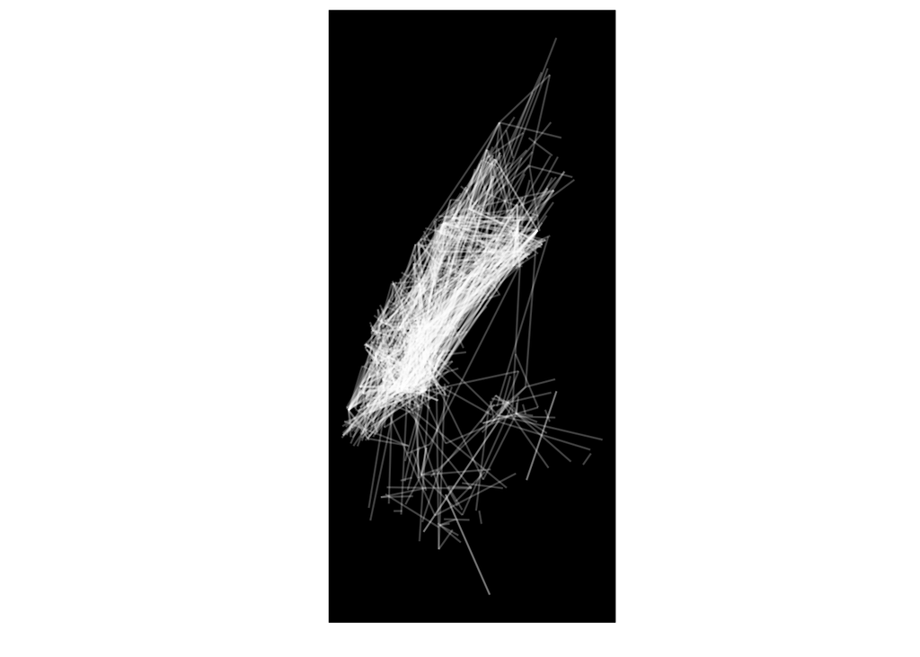

```r
#car
ggplot(pmcar, aes(pmcar$pickup_lon, pmcar$pickup_lat))+
    geom_segment(aes(x=pmcar$pickup_lon, y=pmcar$pickup_lat,xend=pmcar$dropoff_lon, yend=pmcar$dropoff_lat, alpha=filler), col = 'white')+
    scale_alpha_continuous(range = c(0.5, 0.01),guide = FALSE)+
  theme(panel.background = element_rect(fill='black',colour='black'))+
  quiet+
  coord_equal()
```

Are we sending walkers on long metropolitan hikes? We see some occurrences of walkers traversing long distances to deliver food. Walking is probably the slowest form of transportation, and Jumpman23 should limit the distance traveled in the future to optimize efficiency. Walking zones should be metropolitan only. Looks like they do a good job of controlling for this based on the sample.

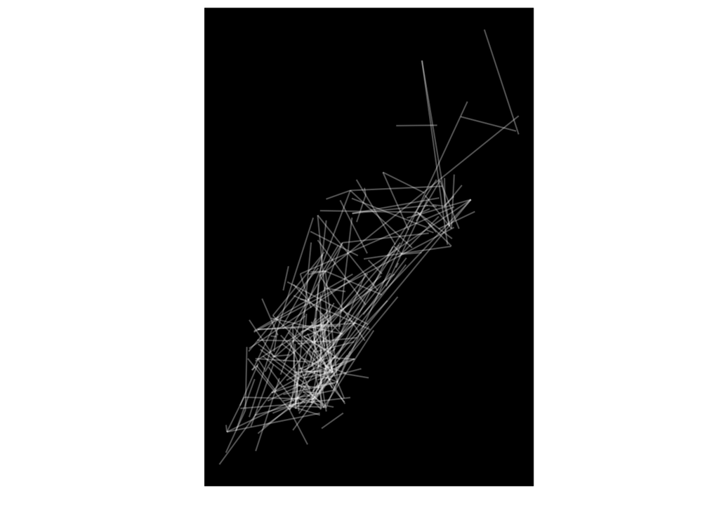

```r
#walker
ggplot(pmwalker, aes(pmwalker$pickup_lon, pmwalker$pickup_lat))+
    geom_segment(aes(x=pmwalker$pickup_lon, y=pmwalker$pickup_lat,xend=pmwalker$dropoff_lon, yend=pmwalker$dropoff_lat, alpha=filler), col = 'white')+
    scale_alpha_continuous(range = c(0.5, 0.1),guide = FALSE)+
  theme(panel.background = element_rect(fill='black',colour='black'))+
  quiet+
  coord_equal()
```

Heat Maps and Time of Day Analysis

The most popular time of day for orders is during lunch and dinner. We see more popularity during dinner than lunch. Advise to factor in a price by demand strategy, or to encourage more Jumpmen to be active during this time.

```r
#popularity by day of week
#popularity by time of day

stripped <- strptime(pm$when_the_delivery_started, format = "%Y-%m-%d %H:%M:%S")
```

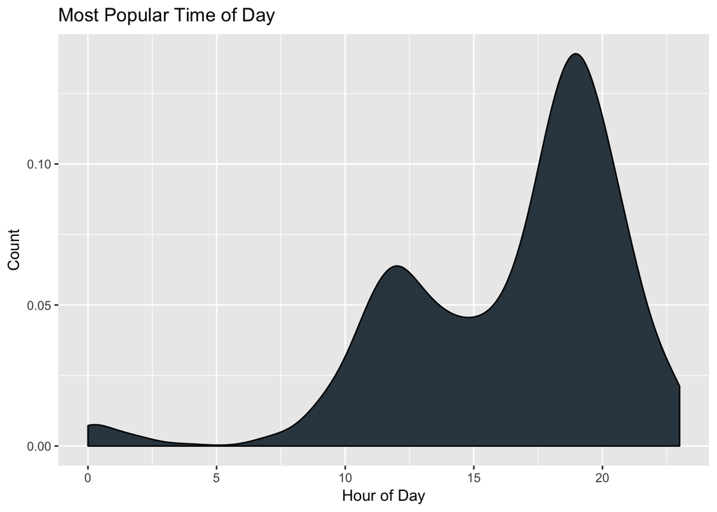

```r
hours <- hour(stripped)
hours <- as.data.frame(hours)
names(hours) <- "Hour"

ggplot(hours, aes(hours)) +
  geom_density(fill = "#36454f") +
  labs(x="Hour of Day", y="Count") +
  ggtitle("Most Popular Time of Day")
```

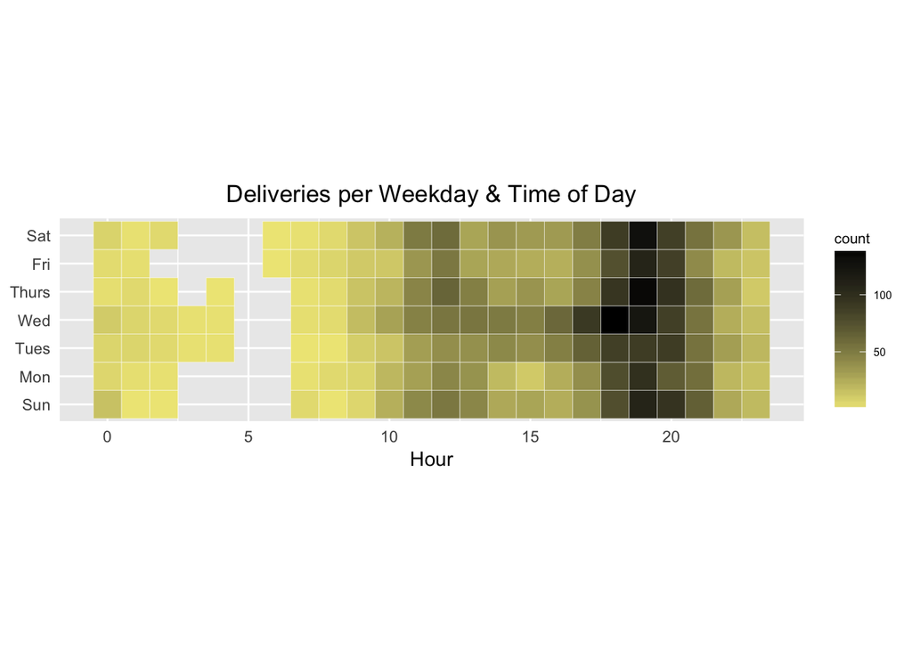

```r
#which day of week?/Hour
dayOfWeek <- weekdays(stripped)
df1 <- cbind(hours, dayOfWeek)
df1 <- as.data.frame(df1)
names(df1) <- c("Hour", "Day_Of_Week")


heatmap <- df1 %>%
  group_by(
    Hour,
     Day_Of_Week
      ) %>%
  summarise(
    count = n()
  )

ggplot(heatmap, aes(x = Hour, y=Day_Of_Week, fill = count)) +
geom_tile( aes(fill = count),color = "white", size = 0.1) +
coord_equal() +
labs( y = NULL, title = "Deliveries per Weekday & Time of Day") +
theme( axis.ticks = element_blank(),
       plot.title = element_text(hjust = 0.5),
       legend.title = element_text(size = 8),
       legend.text = element_text(size = 6) ) +
  scale_y_discrete(labels=c("Sun","Mon","Tues","Wed","Thurs","Fri","Sat")) +
  scale_fill_gradient(low = "khaki2", high = "black")
```